# Aggregating data spatially, and making glyph maps

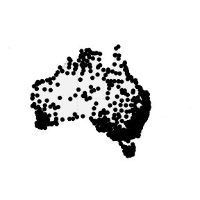

```r
state_map <- st_simplify(ozmaps::abs_ste, dTolerance = 4000)
ggplot() +
  geom_sf(data = state_map, inherit.aes = FALSE,
          color = "grey80", alpha = 0.4, linetype = 3) +
  geom_point(data = prcp_aus , aes(x = long, y = lat)) +
  theme_void()
```

This is a lot of stations to look at for one climate variable and they can’t all fit into a glyph map. What we can do is to group stations into clusters and look at the aggregated series in the glyph map. In this vignette, I will introduce how to perform aggregation using a hierarchical data structure in cubble.

```r
prcp_aus
```

```
#> # cubble:   id [663]: nested form
#> # bbox:     [113.53, -43.66, 153.64, -10.05]
#> # temporal: wk [dbl], prcp [dbl]
#>    id           long   lat  elev name                wmo_id ts
#>    <chr>       <dbl> <dbl> <dbl> <chr>                <dbl> <list>
#>  1 ASN00001006  128. -15.5   3.8 wyndham aero         95214 <tibble [53 × 2]>
#>  2 ASN00001007  126. -13.8   6   troughton island     94102 <tibble [53 × 2]>
#>  3 ASN00001013  128. -15.5  11   wyndham              94214 <tibble [53 × 2]>
#>  4 ASN00001018  126. -16.4 546   mount elizabeth      94211 <tibble [53 × 2]>
#>  5 ASN00001019  127. -14.3  23   kalumburu            94100 <tibble [53 × 2]>
#>  6 ASN00001020  126. -14.1  51   truscott             95101 <tibble [53 × 2]>
#>  7 ASN00001025  126. -15.4 385   doongan              94215 <tibble [53 × 2]>
#>  8 ASN00002012  128. -18.2 422   halls creek airport  94212 <tibble [53 × 2]>
#>  9 ASN00002032  128. -17.0 203   warmun               94213 <tibble [53 × 2]>
#> 10 ASN00002056  129. -15.8  44   kununurra aero       94216 <tibble [53 × 2]>
#> # … with 653 more rows
```

First we need to assign each station a cluster number. Here we use a simple kmean algorithm based on the distance matrix to create 20 clusters. This creates `station_nested` as a station level nested cubble with a cluster column indicating the group each station belongs to.

```r
station_nested
```

```
#> # cubble:   id [663]: nested form
#> # bbox:     [113.53, -43.66, 153.64, -10.05]
#> # temporal: wk [dbl], prcp [dbl]
#>    id           long   lat  elev name                wmo_id ts       cluster
#>    <chr>       <dbl> <dbl> <dbl> <chr>                <dbl> <list>     <int>
#>  1 ASN00001006  128. -15.5   3.8 wyndham aero         95214 <tibble>      15
#>  2 ASN00001007  126. -13.8   6   troughton island     94102 <tibble>      15
#>  3 ASN00001013  128. -15.5  11   wyndham              94214 <tibble>      15
#>  4 ASN00001018  126. -16.4 546   mount elizabeth      94211 <tibble>      15
#>  5 ASN00001019  127. -14.3  23   kalumburu            94100 <tibble>      15
#>  6 ASN00001020  126. -14.1  51   truscott             95101 <tibble>      15
#>  7 ASN00001025  126. -15.4 385   doongan              94215 <tibble>      15
#>  8 ASN00002012  128. -18.2 422   halls creek airport  94212 <tibble>      15
#>  9 ASN00002032  128. -17.0 203   warmun               94213 <tibble>      15
#> 10 ASN00002056  129. -15.8  44   kununurra aero       94216 <tibble>      15
#> # … with 653 more rows
```

To create a group level cubble, use `switch_key()` with the new key variable, `cluster`:

```r
cluster_nested <- station_nested %>%  switch_key(cluster)
cluster_nested %>%  head(5)
```

```
#> # cubble:   cluster [5]: nested form
#> # bbox:     [118.84, -43.66, 152.87, -10.05]
#> # temporal: id [chr], wk [dbl], prcp [dbl]
#>   cluster .val              ts
#>     <int> <list>            <list>
#> 1       1 <tibble [18 × 6]> <tibble [954 × 3]>
#> 2       2 <tibble [51 × 6]> <tibble [2,677 × 3]>
#> 3       3 <tibble [19 × 6]> <tibble [1,007 × 3]>
#> 4       4 <tibble [6 × 6]>  <tibble [318 × 3]>
#> 5       5 <tibble [63 × 6]> <tibble [3,339 × 3]>
```

The resulted `cluster_nested` now has `cluster` as the key and all the station level time invariant variables are nested inside `.val`. Currently, there is no cluster level time invariant variables and we can add the centroid of each cluster by `get_centroid()`:

```r
(cluster_nested <- cluster_nested %>%  get_centroid())
```

```
#> # cubble:   cluster [20]: nested form
#> # bbox:     [113.53, -43.66, 153.64, -10.05]
#> # temporal: id [chr], wk [dbl], prcp [dbl]
#>    cluster .val              ts                   hull     cent_long cent_lat
#>      <int> <list>            <list>               <list>       <dbl>    <dbl>
#>  1       1 <tibble [18 × 6]> <tibble [954 × 3]>   <tibble>      141.    -22.9
#>  2       2 <tibble [51 × 6]> <tibble [2,677 × 3]> <tibble>      147.    -41.8
#>  3       3 <tibble [19 × 6]> <tibble [1,007 × 3]> <tibble>      121.    -30.6
#>  4       4 <tibble [6 × 6]>  <tibble [318 × 3]>   <tibble>      143.    -11.9
#>  5       5 <tibble [63 × 6]> <tibble [3,339 × 3]> <tibble>      150.    -32.3
#>  6       6 <tibble [56 × 6]> <tibble [2,951 × 3]> <tibble>      151.    -28.2
#>  7       7 <tibble [21 × 6]> <tibble [1,113 × 3]> <tibble>      145.    -29.5
#>  8       8 <tibble [61 × 6]> <tibble [3,233 × 3]> <tibble>      117.    -31.2
#>  9       9 <tibble [58 × 6]> <tibble [3,074 × 3]> <tibble>      148.    -35.3
#> 10      10 <tibble [55 × 6]> <tibble [2,915 × 3]> <tibble>      145.    -37.8
#> 11      11 <tibble [37 × 6]> <tibble [1,961 × 3]> <tibble>      142.    -36.1
#> 12      12 <tibble [29 × 6]> <tibble [1,537 × 3]> <tibble>      149.    -23.6
#> 13      13 <tibble [16 × 6]> <tibble [848 × 3]>   <tibble>      130.    -27.3
#> 14      14 <tibble [26 × 6]> <tibble [1,378 × 3]> <tibble>      143.    -17.7
#> 15      15 <tibble [19 × 6]> <tibble [1,007 × 3]> <tibble>      125.    -17.7
#> 16      16 <tibble [48 × 6]> <tibble [2,544 × 3]> <tibble>      139.    -33.9
#> 17      17 <tibble [20 × 6]> <tibble [1,060 × 3]> <tibble>      116.    -23.7
#> 18      18 <tibble [17 × 6]> <tibble [901 × 3]>   <tibble>      134.    -17.3
#> 19      19 <tibble [24 × 6]> <tibble [1,272 × 3]> <tibble>      132.    -13.0
#> 20      20 <tibble [19 × 6]> <tibble [1,007 × 3]> <tibble>      137.    -30.3
```

You can also use `face_temporal()` to get the cluster level long cubble:

```r
(cluster_long <- cluster_nested %>%  face_temporal(ts))
```

```
#> # cubble:  wk, cluster [20]: long form
#> # bbox:    [113.53, -43.66, 153.64, -10.05]
#> # spatial: id [chr], long [dbl], lat [dbl], elev [dbl], name [chr], wmo_id
#> #   [dbl], hull [list], cent_long [dbl], cent_lat [dbl]
#>    cluster id             wk  prcp
#>      <int> <chr>       <dbl> <dbl>
#>  1       1 ASN00015602     1   256
#>  2       1 ASN00015602     2  1554
#>  3       1 ASN00015602     3     8
#>  4       1 ASN00015602     4   184
#>  5       1 ASN00015602     5  2022
#>  6       1 ASN00015602     6    80
#>  7       1 ASN00015602     7    44
#>  8       1 ASN00015602     8    28
#>  9       1 ASN00015602     9   102
#> 10       1 ASN00015602    10  1658
#> # … with 35,086 more rows
```

Now we should have access to both station and cluster level in the nested and long form. Let’s summarise them within a diagram:

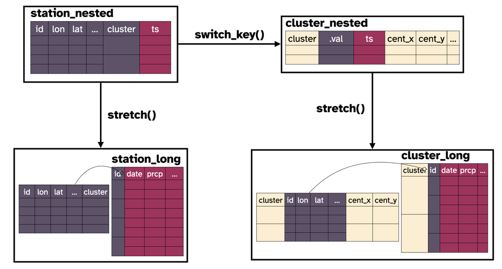

With these data, we can make a glyph map to understand the precipitation pattern in Australia:

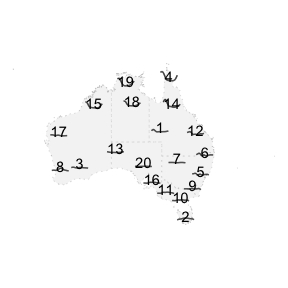

Or to inspect the station membership of each cluster:

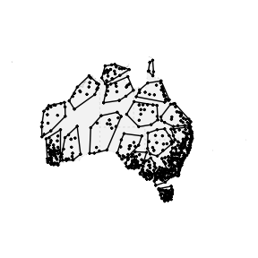

```r
ggplot() +
  geom_sf(data = state_map, inherit.aes = FALSE,
          color = "grey80", alpha = 0.4, linetype = 3) +
  geom_point(data = station_nested, aes(x = long, y = lat), size = 0.5) +
  ggforce::geom_mark_hull(
    data = cluster_nested %>% tidyr::unnest(hull),
    expand = 0, radius = 0,
    aes(x = long, y = lat, group = cluster)) +
  theme_void()
```